# Are Capitalism & Communism Philosophy?

Gexin Chen

2/2/2022

# 0. Introduction

#### This notebook aims to explore the nature of Capitalism and Communism by comparing them with other modern philosophy theories.

#### Dataset: The CSV file can be accessed from Kaggle: https://www.kaggle.com/vanvalkenberg/nlp-what-the-philosopher-said

“Are Communism and Capitalism concluded as theories of philosophy or sociology?” It has become an extremely common question for those without enough exposure to the area of philosophy, including myself. This question has been bothering me for a really long time.  
Even though I cannot figure out this question as a philosophor or sociologist, I will try to use data and analysis technics to find the answer as a data scientist.  
From now, the works from capitalism and communism are called experiment group while the works from other modern philosphy school are annotated as control group.

The philosophy works used for analysis are listed below: (Since all knowledge and understanding may be dynamic and changing over time, I will only investigate the philosophy works during the same period.)

```
##                                                    title         author
## 1                  Dialogues Concerning Natural Religion           Hume
## 2                                   The Analysis Of Mind        Russell
## 3                             The Problems Of Philosophy        Russell
## 4                                  Philosophical Studies          Moore
## 5                         Tractatus Logico-Philosophicus   Wittgenstein
## 6                        The Phenomenology Of Perception  Merleau-Ponty
## 7  The Crisis Of The European Sciences And Phenomenology        Husserl
## 8                              The Idea Of Phenomenology        Husserl
## 9                                         Being And Time      Heidegger
## 10                          Critique Of Practical Reason           Kant
## 11                                 Critique Of Judgement           Kant
## 12                               Critique Of Pure Reason           Kant
## 13                                  The System Of Ethics         Fichte
## 14                                      Science Of Logic          Hegel
```

[output cut: 45 more lines]

Before diving into the analysis of word frequency, we would like to do some basic exploratory data analysis.

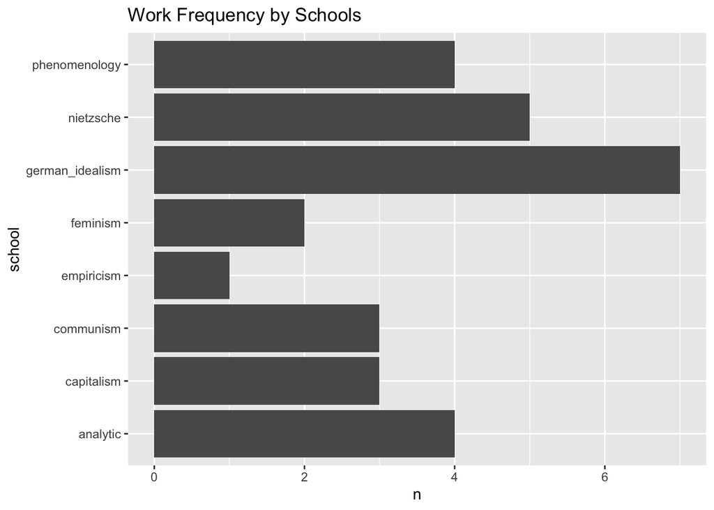

The number of philosophy works from different schools is not evenly distributed: there are three works from capitalism, communism while seven works are published from germam idealism.

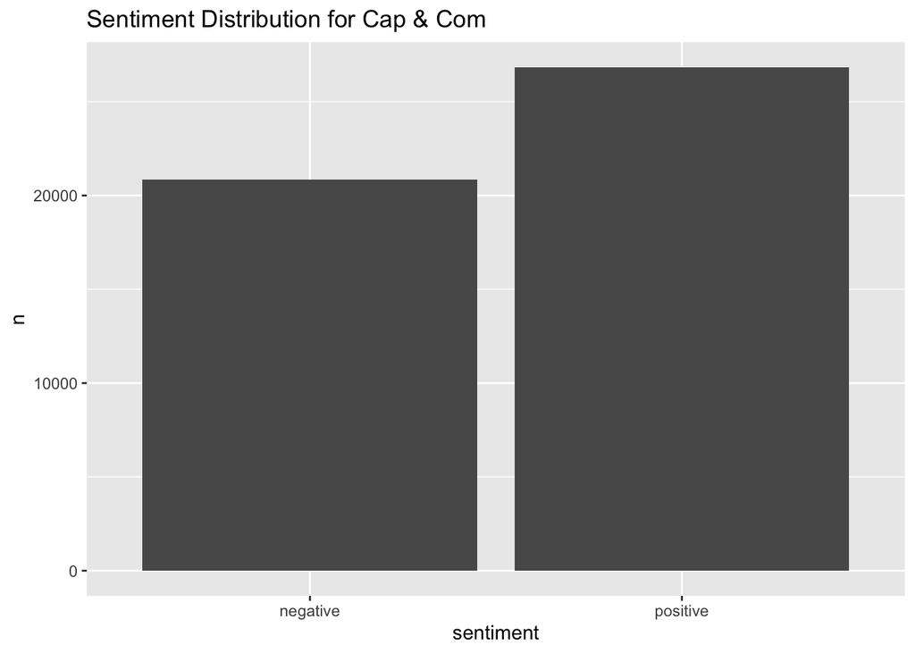

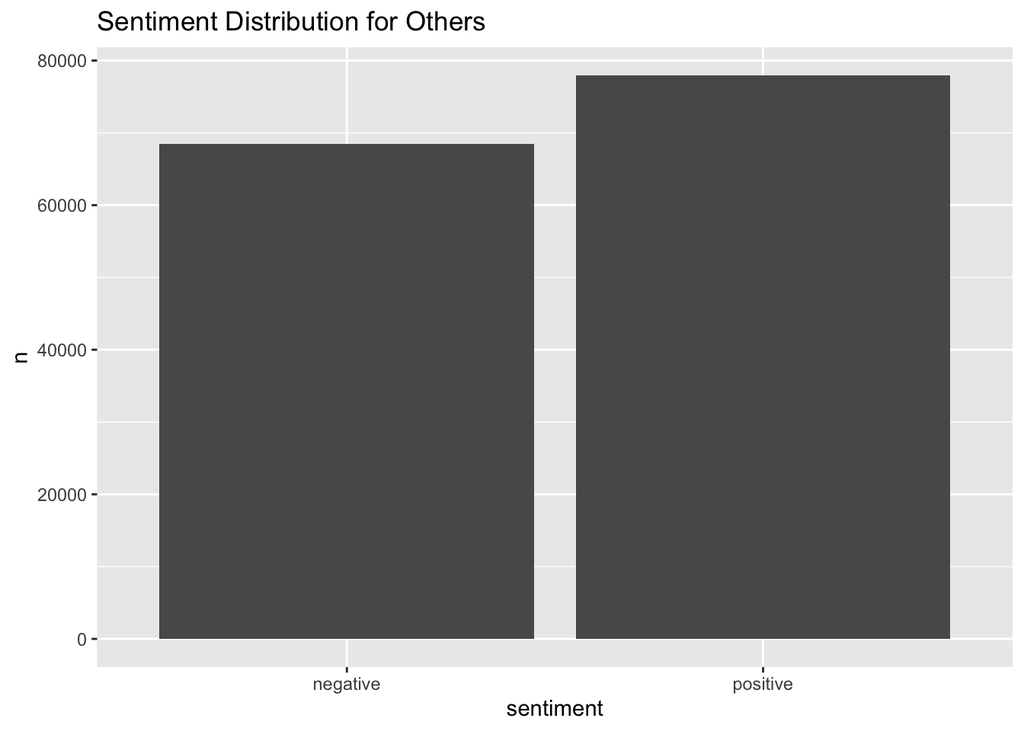

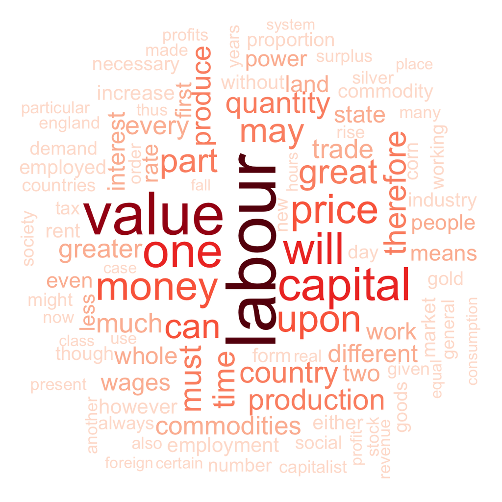

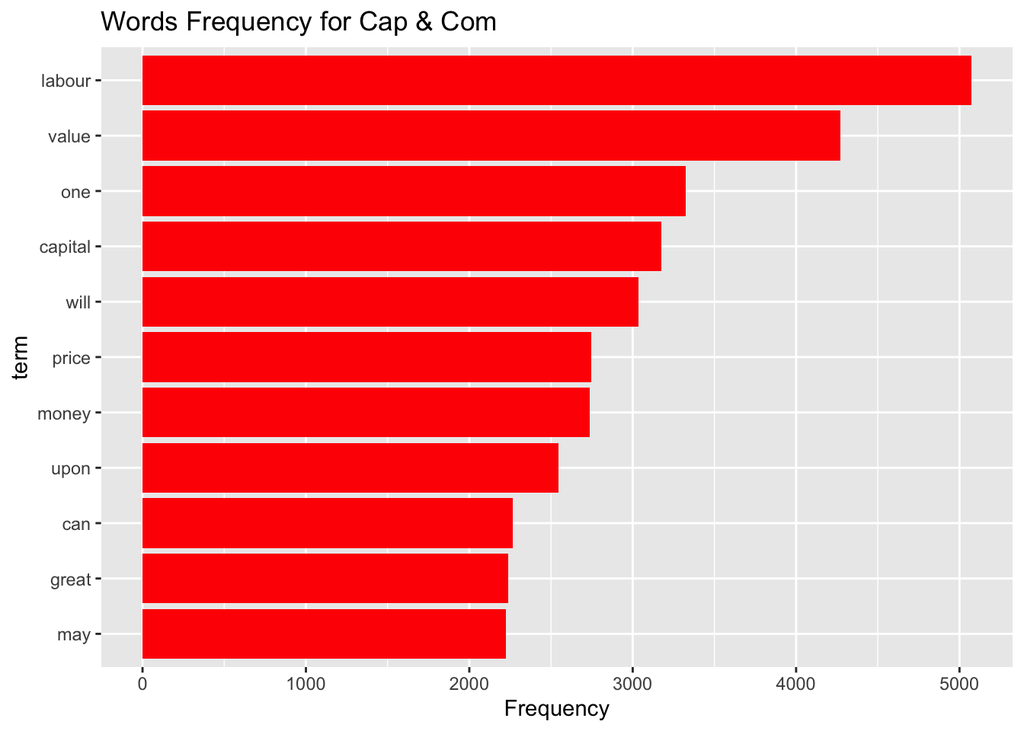

From plots above, it can be noticed that words like labour, money, capital, value and price occur with the highest frequency.  
However, it could be possible that these words’ high frequency is solely caused by Communism work or Capitalism work. Therefore, we also divide up Communism work and Capitalism work to avoid discrepencies.

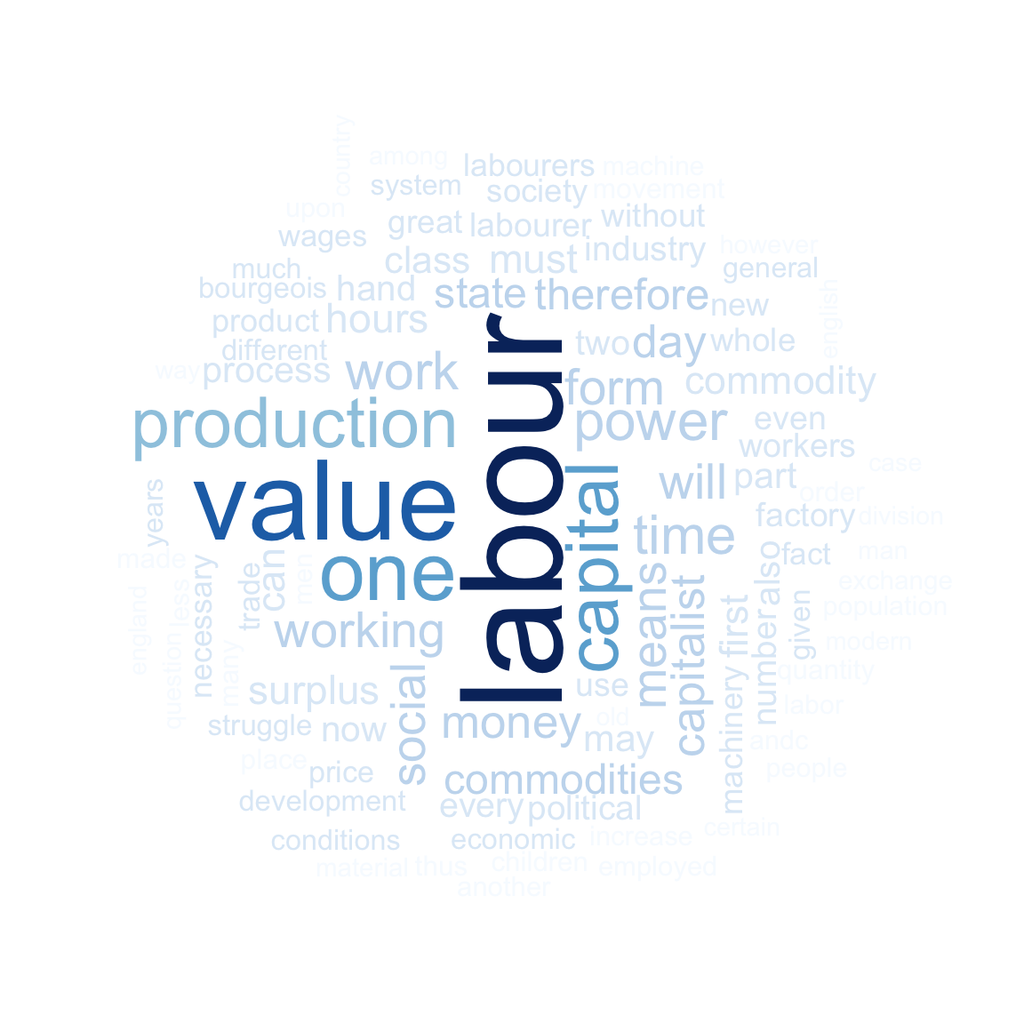

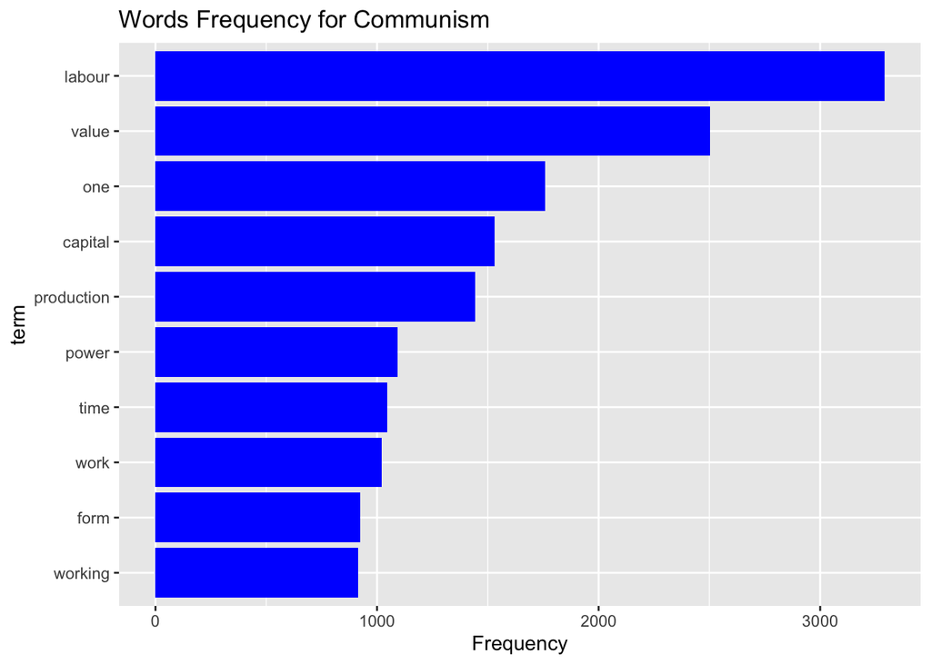

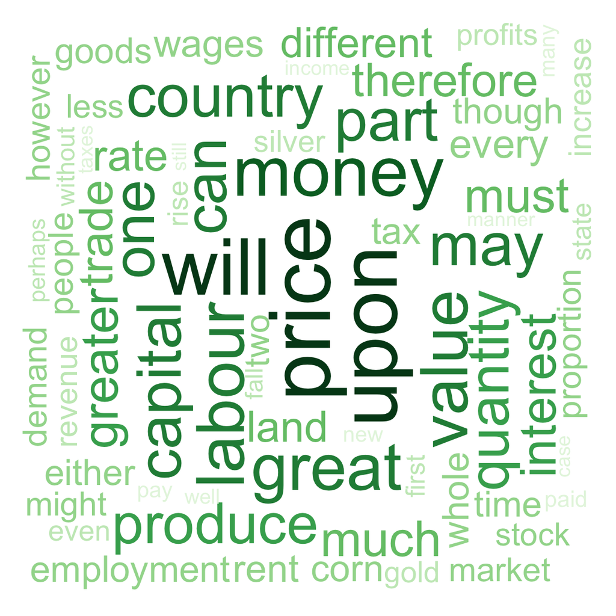

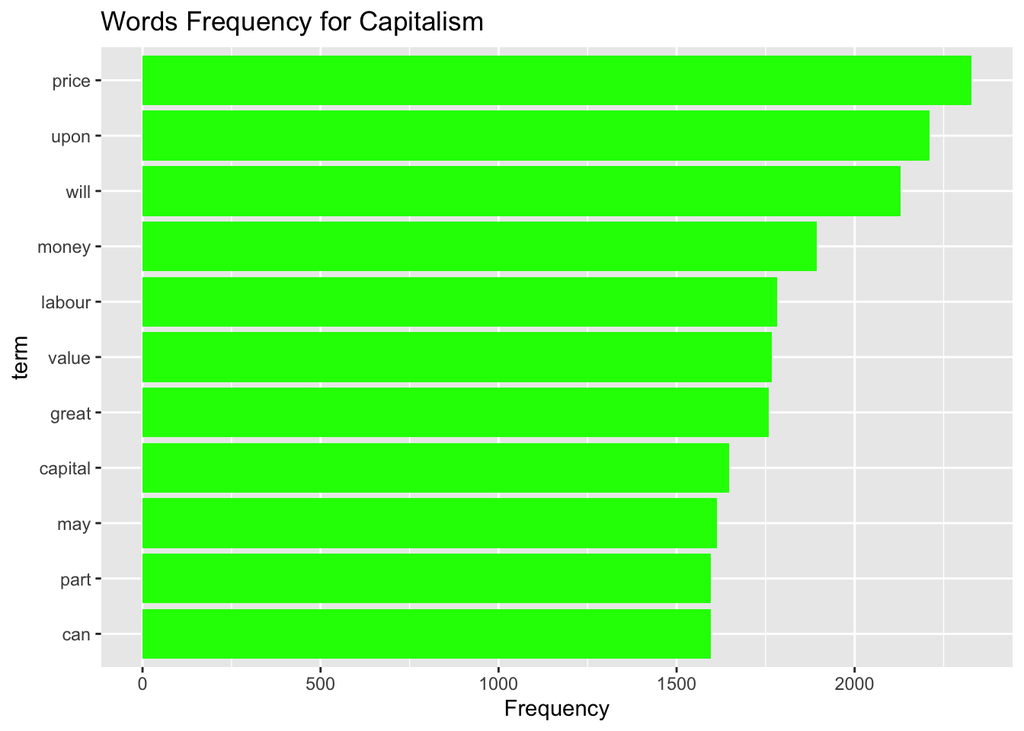

## Rest of Modern Philosophy

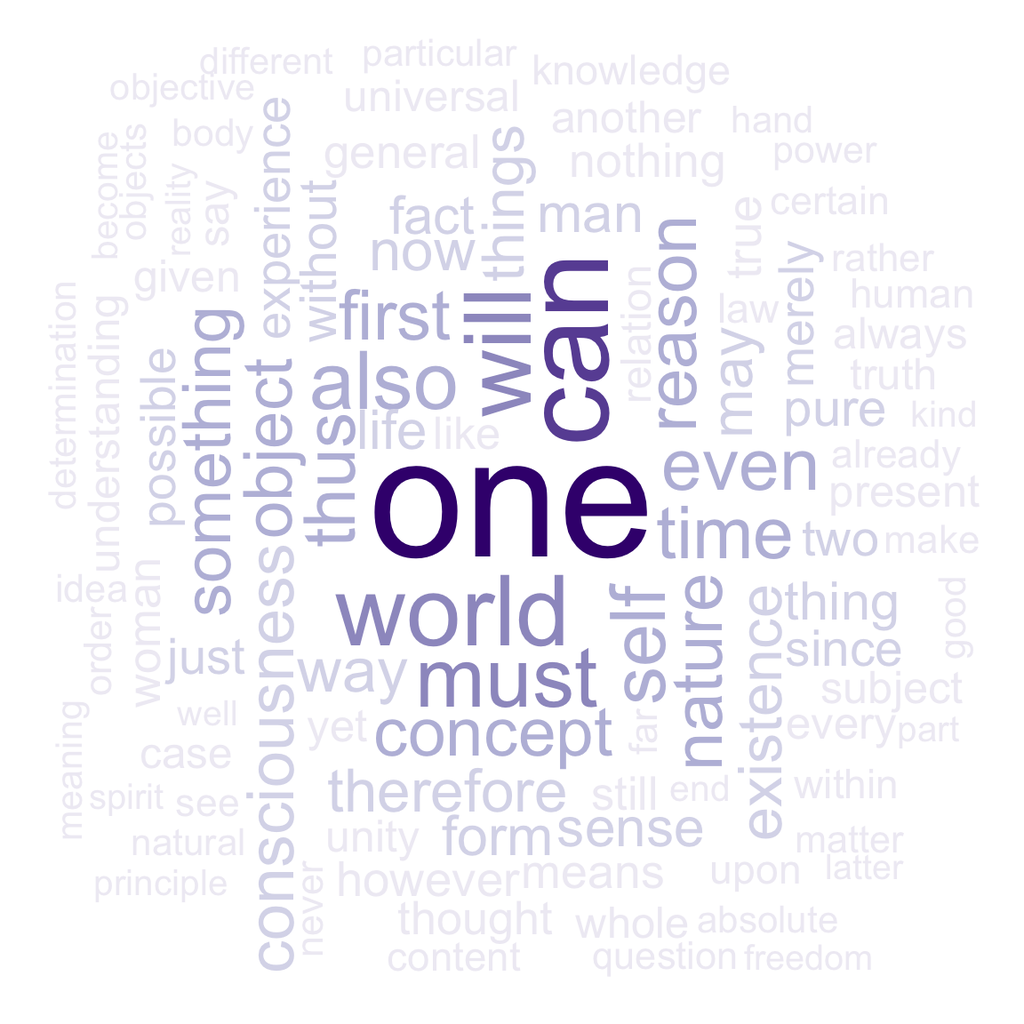

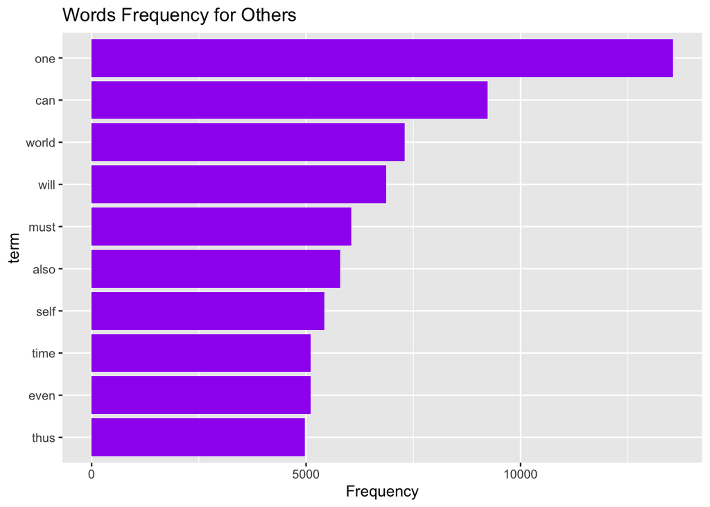

In other modern philosophy works, the most frequent words including one, must, will, can etc. are not informative.  
Therefore, we need further process the data in order for more information.

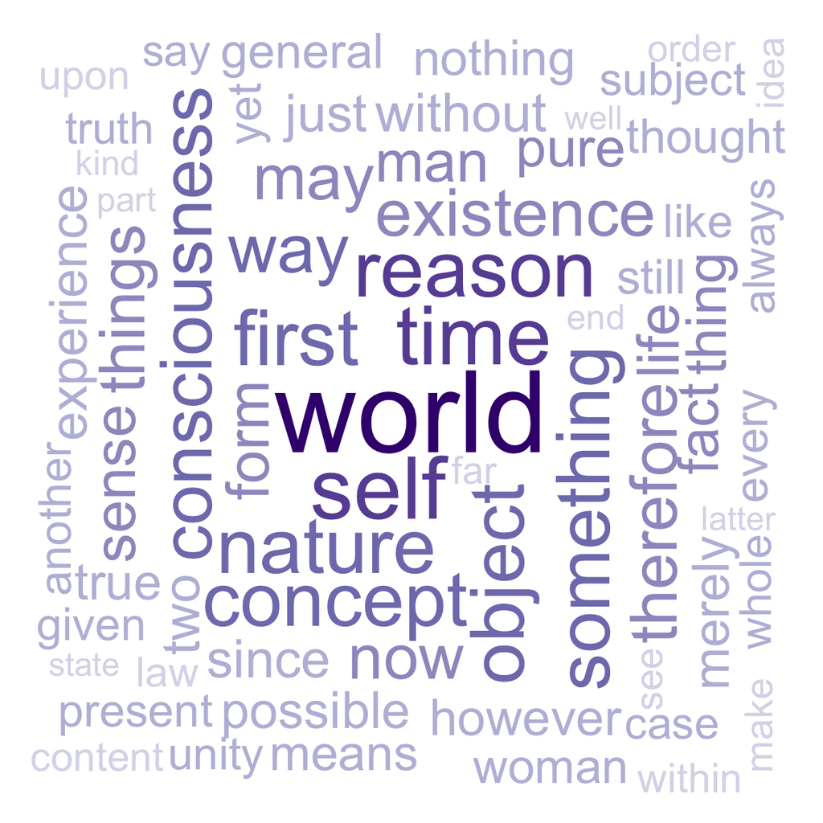

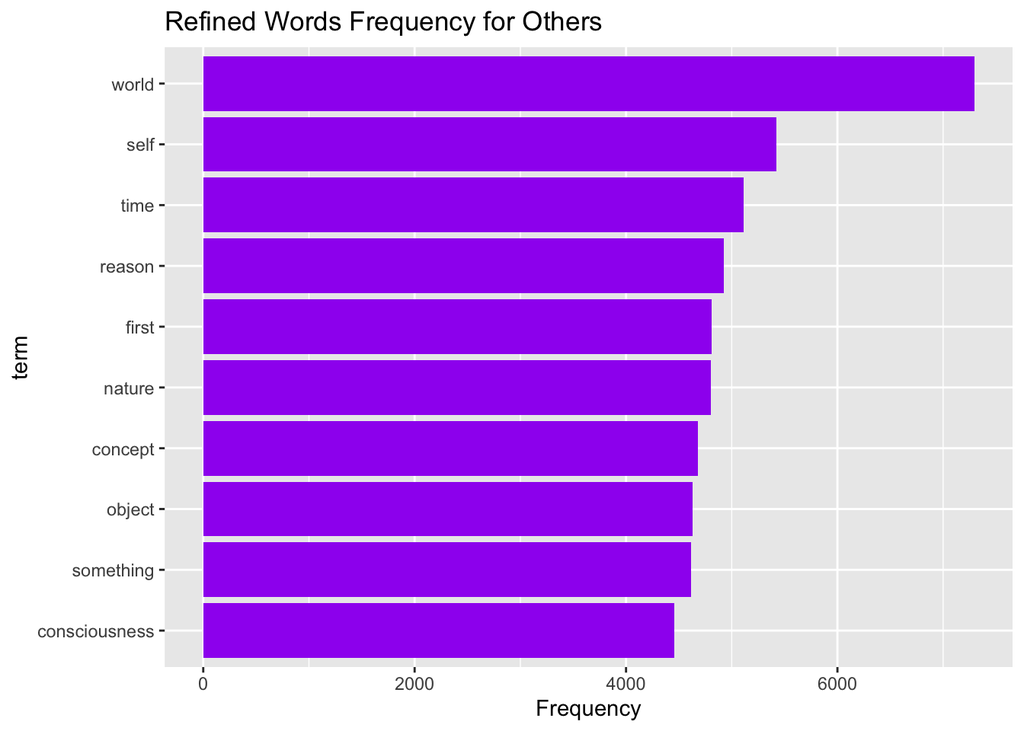

After removing uninformative words in datasets, it can found that the most frequent words include nature, reason, concept and so on.  
It can be said with certainty that the content from Communism and Capitalism work is different from other modern philosophy works.

# 3. Conclusion